# notebook_2_tests-conditions-adverses

### 8.2 `ResNet Inspired Model`

```python
model = load_model('/kaggle/input/cnn-resnet-inspired-for-traffic-sign/tensorflow2/default/1/FinalOptimizedResNetModel_1.h5')
print('FinalOptimizedResNetModel loaded !')
```

```
FinalOptimizedResNetModel loaded !
```

#### 8.2.1 `ResNet Inspired Model` - test en condition adverse *(not retrained)*

Les performances montrent une robustesse modérée à ces transformations, avec une précision et un rappel proches de 94%, indiquant que même sans entraînement, le modèle conserve une capacité à capturer des motifs visuels.  
Cependant, le manque d'optimisation pour des classes spécifiques se reflète dans les scores légèrement inférieurs comparés à un modèle bien entraîné.

```
Test en conditions adverse 'non entraîné'
```

[output not shown]

```
 31/297 ━━━━━━━━━━━━━━━━━━━━ 1s 5ms/step
```

```
I0000 00:00:1728215804.205976     253 device_compiler.h:188] Compiled cluster using XLA!  This line is logged at most once for the lifetime of the process.
```

```
297/297 ━━━━━━━━━━━━━━━━━━━━ 4s 7ms/step
--- Performance Metrics for resnet_inspired_model ---
```

|  | precision | recall | f1-score | support |
| --- | --- | --- | --- | --- |
| accuracy | 0.944000 | 0.944000 | 0.944000 | 0.944000 |
| macro avg | 0.949000 | 0.945000 | 0.945000 | 9475.000000 |
| weighted avg | 0.948000 | 0.944000 | 0.944000 | 9475.000000 |
| AUC-ROC | 0.998999 | 0.998999 | 0.998999 | 0.998999 |
| Average Precision | 0.984939 | 0.984939 | 0.984939 | 0.984939 |

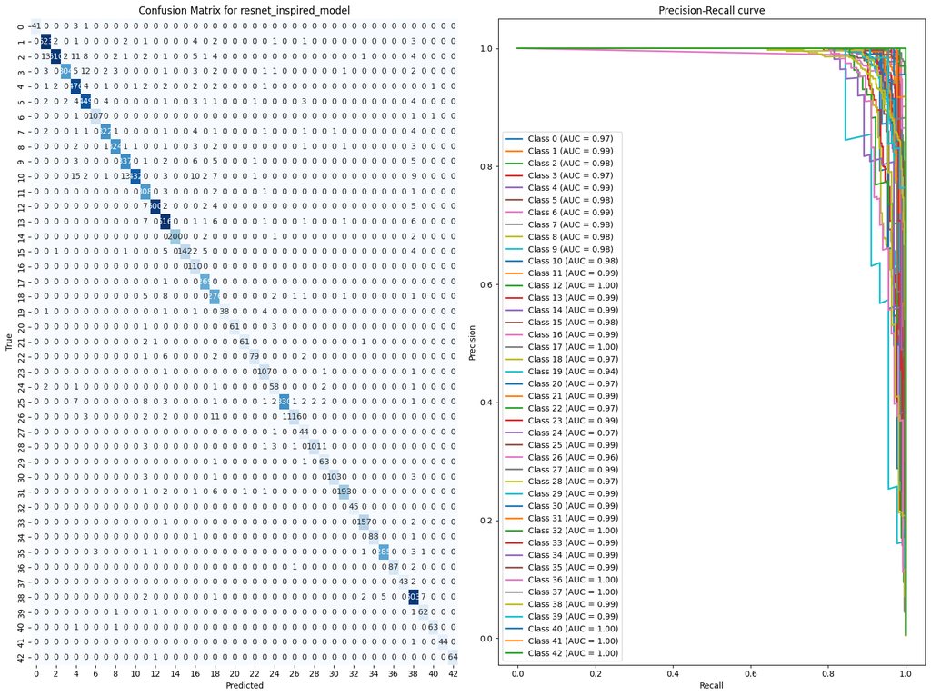

```python
print("\nTest en conditions adverse 'non entraîné'")
metrics_df = evaluate_model(model, 'resnet_inspired_model', X_test, y_test, num_classes=43)
```

#### 8.2.2 `ResNet Inspired Model` - Training

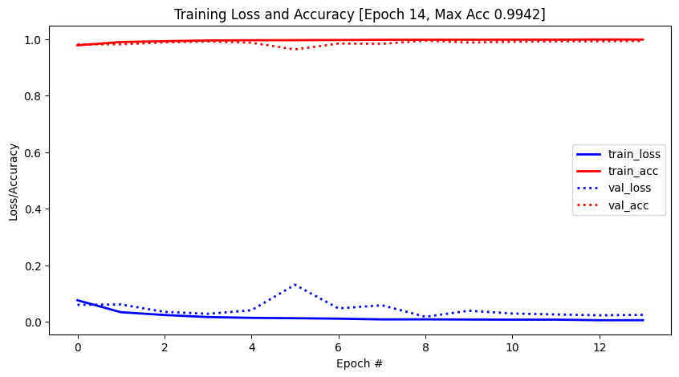

```
2763/2763 ━━━━━━━━━━━━━━━━━━━━ 26s 9ms/step - accuracy: 0.9985 - loss: 0.0050 - val_accuracy: 0.9929 - val_loss: 0.0250
```

```python
with open('/kaggle/input/cnn-resnet-inspired-for-traffic-sign/tensorflow2/default/1/best_resnet_params.json', 'r') as f:
        best_params = json.load(f)

model.compile(optimizer=Adam(learning_rate=best_params['learning_rate']),
                           loss='categorical_crossentropy',
                           metrics=['accuracy'])

earlystop = callbacks.EarlyStopping(monitor='val_loss', patience=5, restore_best_weights=True)
plot_losses = TrainingPlot()
history = model.fit(X_train, y_train, validation_data=(X_val, y_val),
                        epochs=100, batch_size=best_params['batch_size'],
                        callbacks=[plot_losses, earlystop])
```

#### 8.2.3 `ResNet Inspired Model` - test en condition adverse *(retrained)*

Le modèle entraîné a montré des performances nettement améliorées en conditions adverses après l'entraînement.  
L'augmentation de la précision et du rappel à environ 99.5% reflète la capacité du modèle à généraliser et à reconnaître les signes malgré les perturbations appliquées.  
L'amélioration des scores de l'AUC-ROC et de la précision moyenne souligne la capacité du modèle à discriminer efficacement entre les classes.

```
Test en conditions adverse 'model entraîné'
297/297 ━━━━━━━━━━━━━━━━━━━━ 2s 6ms/step
--- Performance Metrics for resnet_inspired_model ---
```

|  | precision | recall | f1-score | support |
| --- | --- | --- | --- | --- |
| accuracy | 0.995000 | 0.995000 | 0.995000 | 0.995000 |
| macro avg | 0.996000 | 0.994000 | 0.995000 | 9475.000000 |
| weighted avg | 0.995000 | 0.995000 | 0.995000 | 9475.000000 |
| AUC-ROC | 0.999991 | 0.999991 | 0.999991 | 0.999991 |
| Average Precision | 0.999699 | 0.999699 | 0.999699 | 0.999699 |

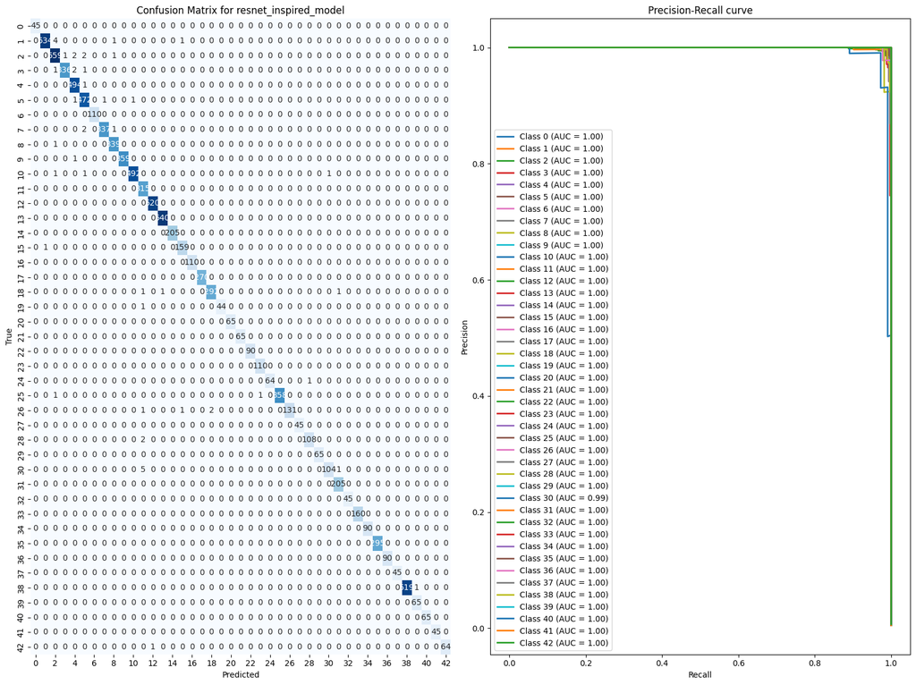

```python
print("Test en conditions adverse 'model entraîné'")
metrics_df = evaluate_model(model, 'resnet_inspired_model', X_test, y_test, num_classes=43)
```

### 8.3 `CNN Regularized Model`

#### 8.3.1 `CNN Regularized Model` - test en condition adverse *(not retrained)*

Le modèle non entraîné a été testé dans les mêmes conditions adverses que le modèle ResNet Inspired.  
Bien que les résultats soient légèrement inférieurs, avec une précision et un rappel de 92%, les scores restent acceptables pour un modèle non optimisé.  
Ces résultats suggèrent une bonne capacité du modèle à gérer des distorsions, mais des améliorations seraient nécessaires pour atteindre les niveaux de performance observés après un entraînement complet.

```
FinalOptimizedRegularizedCNNModel loaded !

Test en conditions adverse 'non entraîné'
297/297 ━━━━━━━━━━━━━━━━━━━━ 2s 4ms/step
--- Performance Metrics for cnn_regularized_model ---
```

|  | precision | recall | f1-score | support |
| --- | --- | --- | --- | --- |
| accuracy | 0.922000 | 0.922000 | 0.922000 | 0.922000 |
| macro avg | 0.912000 | 0.922000 | 0.913000 | 9475.000000 |
| weighted avg | 0.930000 | 0.922000 | 0.924000 | 9475.000000 |
| AUC-ROC | 0.995395 | 0.995395 | 0.995395 | 0.995395 |
| Average Precision | 0.958185 | 0.958185 | 0.958185 | 0.958185 |

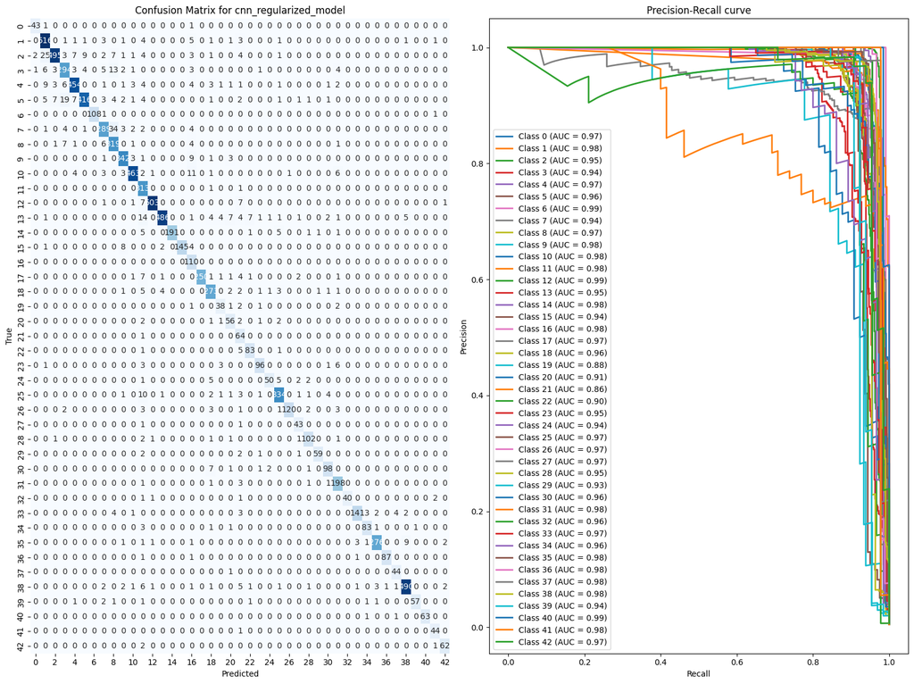

```python
model = load_model('/kaggle/input/cnn-regularized-for-traffic-signifie-recognition/tensorflow2/default/1/FinalOptimizedRegularizedCNNModel_1.h5')
print('FinalOptimizedRegularizedCNNModel loaded !')

print("\nTest en conditions adverse 'non entraîné'")
metrics_df = evaluate_model(model, 'cnn_regularized_model', X_test, y_test, num_classes=43)
```

#### 8.3.2 `CNN Regularized Model` - Training

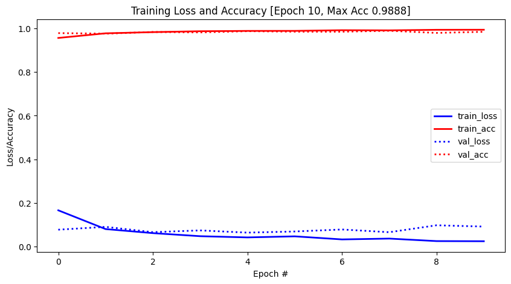

```
2763/2763 ━━━━━━━━━━━━━━━━━━━━ 11s 4ms/step - accuracy: 0.9936 - loss: 0.0227 - val_accuracy: 0.9842 - val_loss: 0.0918
```

```python
with open('/kaggle/input/cnn-regularized-for-traffic-signifie-recognition/tensorflow2/default/1/best_regularized_cnn_params.json', 'r') as f:
        best_params = json.load(f)

model.compile(optimizer=Adam(learning_rate=best_params['learning_rate']),
                           loss='categorical_crossentropy',
                           metrics=['accuracy'])

earlystop = callbacks.EarlyStopping(monitor='val_loss', patience=5, restore_best_weights=True)
plot_losses = TrainingPlot()
history = model.fit(X_train, y_train, validation_data=(X_val, y_val),
                        epochs=100, batch_size=best_params['batch_size'],
                        callbacks=[plot_losses, earlystop])
```

#### 8.3.3 `CNN Regularized Model` - test en condition adverse *(retrained)*

Le modèle entraîné a montré des performances très compétitives, avec une précision et un rappel avoisinant 98.7%.  
La régularisation semble avoir aidé à rendre le modèle robuste aux perturbations, tout en améliorant sa capacité à distinguer les classes.  
L'AUC-ROC proche de 1 et la précision moyenne presque parfaite démontrent l'efficacité de ce modèle dans des conditions difficiles après optimisation.

```
Test en conditions adverse 'model entraîné'
297/297 ━━━━━━━━━━━━━━━━━━━━ 1s 3ms/step
--- Performance Metrics for cnn_regularized_model ---
```

|  | precision | recall | f1-score | support |
| --- | --- | --- | --- | --- |
| accuracy | 0.987000 | 0.987000 | 0.987000 | 0.987000 |
| macro avg | 0.988000 | 0.988000 | 0.988000 | 9475.000000 |
| weighted avg | 0.987000 | 0.987000 | 0.987000 | 9475.000000 |
| AUC-ROC | 0.999950 | 0.999950 | 0.999950 | 0.999950 |
| Average Precision | 0.998502 | 0.998502 | 0.998502 | 0.998502 |

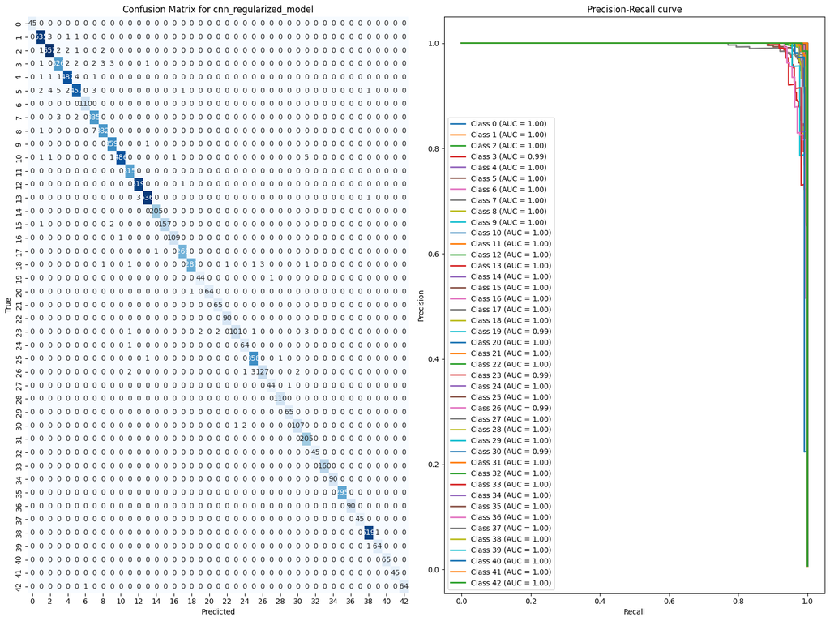

```python
print("Test en conditions adverse 'model entraîné'")
metrics_df = evaluate_model(model, 'cnn_regularized_model', X_test, y_test, num_classes=43)
```

### 8.4 Conclusion

#### 8.4.1 Synthèse des résultats

Les deux modèles, le ResNet Inspired et le CNN Regularized, ont montré de bonnes performances dans des conditions adverses après l'entraînement, avec des scores très élevés pour la précision, le rappel et l'AUC-ROC. Avant l'entraînement, les deux modèles ont montré des résultats corrects mais inférieurs, reflétant leur état non optimisé. Le modèle ResNet Inspired a légèrement surpassé le modèle CNN en termes de robustesse aux perturbations une fois entraîné, bien que les deux soient proches en termes de performances globales.

| **Modèle** | **État** | **Précision** | **Rappel** | **F1-score** | **AUC-ROC** | **Précision Moyenne** |
| --- | --- | --- | --- | --- | --- | --- |
| **ResNet Inspired** | not retrained | 94.4% | 94.4% | 94.4% | 99.9% | 98.5% |
| **ResNet Inspired** | retrained | 99.5% | 99.5% | 99.5% | 99.99% | 99.97% |
| **CNN Regularized** | not retrained | 92.2% | 92.2% | 92.2% | 99.5% | 95.8% |
| **CNN Regularized** | retrained | 98.7% | 98.7% | 98.7% | 99.99% | 99.85% |

#### 8.4.2 Choix du model

En tenant compte des performances en conditions adverses, du temps d'entraînement et de la capacité de généralisation, le modèle ResNet Inspired semble être le meilleur choix pour cette tâche. Son architecture permet d'apprendre des représentations plus profondes, ce qui explique ses scores légèrement supérieurs. Cependant, le CNN Regularized pourrait être une alternative intéressante pour des cas d'usage nécessitant moins de complexité et de ressources de calcul, tout en offrant des performances comparables.